# Pseudotime Sexual Branch wild-type cells only

Gametocyte Development in *Plasmodium berghei

[Andrew Russell](https://ajcrussell.wixsite.com/mysite/about)

March 08, 2021

# 1. Introduction and Aims

We have merged the two datasets together in GCSKO_merge_wt.Rmd. We also subsetted out the pre-sexual-branch and the sexual cells (male and female) and stored them in a Seurat object called tenx.justwt.integrated.sex Here, we will perform pseudotime analysis on the dataset and build modules of genes that show similar expression across this pseudotime.

# 2. Read in the data

## Load/Install the Required Packages

```
[1] "patchwork is loaded correctly"
[1] "viridis is loaded correctly"
[1] "Seurat is loaded correctly"
[1] "cowplot is loaded correctly"
[1] "gridExtra is loaded correctly"
[1] "grid is loaded correctly"
[1] "Hmisc is loaded correctly"
[1] "reshape2 is loaded correctly"
[1] "dplyr is loaded correctly"
[1] "circlize is loaded correctly"
[1] "monocle3 is loaded correctly"
[1] "destiny is loaded correctly"
```

## load data

```r
## load sex only branch cells saved from GCSKO_Sex_Branch_Analysis.Rmd
## Restore the objects
## load sex branch dataset
tenx.justwt.integrated.sex <- readRDS("../data_to_export/tenx.justwt.integrated.sex.RDS")
## load full dataset
#tenx.mutant.integrated <- readRDS("../data_to_export/tenx.mutant.integrated.RDS")
```

```r
## add old pt values
## these values are calculated in hte GCSKO_pseudotime_allcells.Rmd script and so were added after the object was split into sex only.
#tenx.all <- readRDS("../data_to_export/tenx.mutant.integrated.RDS")
#tenx.all.meta <- as.data.frame(tenx.all@meta.data)
#tenx.all.meta <- tenx.all.meta[which(rownames(tenx.all.meta) %in% rownames(tenx.mutant.integrated.sex@meta.data)),]
#tenx.mutant.integrated.sex <- AddMetaData(tenx.mutant.integrated.sex, tenx.all.meta$old_pt_values, col.name = "old_pt_values")
## then remove these objects so they don't use up memory
#rm(tenx.all, tenx.all.meta)
```

Add a meta.data column so that 10X is listed as WT:

```r
## get cells that are filtered out
mutant_cells <- which(tenx.justwt.integrated.sex$experiment == "mutants")

## make extra column in plotting df
tenx.justwt.integrated.sex@meta.data$identity_name_combined <- "WT_10X"
tenx.justwt.integrated.sex@meta.data$identity_name_combined[mutant_cells] <- tenx.justwt.integrated.sex@meta.data$identity_name_updated[mutant_cells]

## check
table(tenx.justwt.integrated.sex@meta.data$identity_name_combined)
```

```
wild-type    WT_10X
      419      2398
```

```r
## create a list of our mutant gene IDs
list_of_mutant_genes <- c("PBANKA-0828000", "PBANKA-1302700", "PBANKA-1447900", "PBANKA-0102400", "PBANKA-0716500", "PBANKA-1435200", "PBANKA-1418100", "PBANKA-1144800", "PBANKA-0902300", "PBANKA-0413400", "PBANKA-1454800")
```

Read in gene annotations

```r
gene_annotations <- read.table("../data/Reference/GenesByTaxon_Summary.csv", header = TRUE, sep = ",", stringsAsFactors = TRUE)
dim(gene_annotations)
```

```
[1] 5254    7
```

```r
## convert _ to -
gene_annotations$Gene.ID <- gsub("_", "-", gene_annotations$Gene.ID)
```

# 3. Monocle on sex cells

## calculate pseudotime and modules

#### Preparation

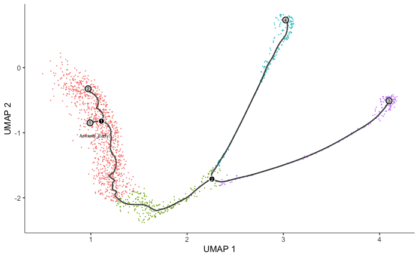

```r
## extracts only 10x cells and also remove cluster 0 cells
wt_cells <- rownames(tenx.justwt.integrated.sex@meta.data[which(tenx.justwt.integrated.sex@meta.data$identity_name_combined == "WT_10X" & !tenx.justwt.integrated.sex@meta.data$seurat_clusters == "3" & !tenx.justwt.integrated.sex@meta.data$seurat_clusters == "6"),])

## make a new Seurat of this
seurat.object <-subset(tenx.justwt.integrated.sex, cells = wt_cells)

## check that this is the same as the pb_sex_filtered object
#data_test <- as(as.matrix(GetAssayData(pb_sex_filtered, assay = "RNA", slot = "data")), 'sparseMatrix')
#is.equal
#is.identical

## extract counts and pheno:
## the reason we use the integrated and then subsetted is because these cells have been normalised whereas the cells in pb_sex_filtered have not been normalised (well they have but with doublets in them)
data <- as(as.matrix(GetAssayData(seurat.object, assay = "RNA", slot = "data")), 'sparseMatrix')
## make phenodata
pd <- data.frame(seurat.object@meta.data)
## keep only the columns that are relevant in metadata
#pData <- pd %>% select(orig.ident, nCount_RNA, nFeature_RNA)
## make gene metadata
fData <- data.frame(gene_short_name = row.names(data), row.names = row.names(data))

## Construct monocle cds
monocle.object <- new_cell_data_set(expression_data = data, cell_metadata = pd, gene_metadata = fData)

## preprocess
monocle.object = preprocess_cds(monocle.object, num_dim = 50, norm_method = "none")
### if using integrated data:
# norm_method = "none", alignment_group = "~ experiment"

## plot jack straw plot
#plot_pc_variance_explained(monocle.object)

#monocle.object = reduce_dimension(monocle.object, reduction_method = "UMAP", preprocess_method = "PCA", umap.metric = "euclidean", umap.n_neighbors = 50, umap.min_dist = 0.5, verbose = FALSE)

#plot_cells(monocle.object, color_cells_by="experiment")

## graph learning

## add UMAP from Seurat
monocle.object@int_colData@listData$reducedDims@listData[["UMAP"]] <- seurat.object@reductions[["umap"]]@cell.embeddings
## if you want the old UMAP from the original all cells one, use: "DIM_UMAP"

## cluster
## this is essential to run the learn_graph function later on
monocle.object = cluster_cells(monocle.object)

## plot initial clustering by monocle
#plot_cells(monocle.object, color_cells_by="cluster", group_cells_by="partition", x = 2, y = 1)

## map pseudotime
monocle.object = learn_graph(monocle.object, learn_graph_control=list(ncenter=550, minimal_branch_len = 30), use_partition = FALSE)
# learn_graph_control=list(ncenter=500) - play with this parameter - lower tends to give fewer branches and higher tends to give more
# 500 - old analysis
# 250 - new analysis

## Plot cells
plot_cells(monocle.object, color_cells_by="monocle_sex", group_cells_by="partition", x = 1, y = 2)
```

Redefine the identities of the male and female cells

male

```r
# monocle.object_male <- choose_graph_segments(monocle.object)
```

female

```r
# monocle.object_female <- choose_graph_segments(monocle.object)
```

bipotential

```r
#monocle.object_bipot <- choose_graph_segments(monocle.object)
```

asexual

```r
#monocle.object_asex <- choose_graph_segments(monocle.object)
```

asexual fate

```r
#monocle.object_asex_fate <- choose_graph_segments(monocle.object)
```

check

```r
# df_freq <- data.frame(table(c(colnames(monocle.object_male), colnames(monocle.object_female), colnames(monocle.object_bipot), colnames(monocle.object_asex), colnames(monocle.object_asex_fate))))
# paste("number of cells in seurat object is", length(colnames(monocle.object)), ". The number of cells selected here with an identitity is", dim(df_freq)[1])
# df_freq <- df_freq[df_freq$Freq > 1, ]
# df_freq
```

Inspect where these missing cells are:

```r
# '%ni%' <- Negate('%in%')
#
# not_assigned_cells <- colnames(monocle.object)[colnames(monocle.object) %ni% c(colnames(monocle.object_male), colnames(monocle.object_female), colnames(monocle.object_bipot), colnames(monocle.object_asex), colnames(monocle.object_asex_fate))]
#
# DimPlot(seurat.object, repel = TRUE, label.size = 5, pt.size = 0.5, cells.highlight = not_assigned_cells, dims = c(2,1), reduction = "DIM_UMAP") +
#   coord_fixed() +
#   scale_color_manual(values=c("#000000", "#f54e1e"))
```

```r
# ## create annotation dataframe from these results:
# df_monocle_sexes <- rbind(data.frame("cell_name" = colnames(monocle.object_male), "sex" = rep("Male", length(colnames(monocle.object_male)))),
#                           data.frame("cell_name" = colnames(monocle.object_female), "sex" = rep("Female", length(colnames(monocle.object_female)))),
#                           data.frame("cell_name" = colnames(monocle.object_bipot), "sex" = rep("Bipotential", length(colnames(monocle.object_bipot)))),
#                           data.frame("cell_name" = colnames(monocle.object_asex), "sex" = rep("Asexual", length(colnames(monocle.object_asex)))),
#                           data.frame("cell_name" = colnames(monocle.object_asex_fate), "sex" = rep("Asexual_Fate", length(colnames(monocle.object_asex_fate)))),
#                           data.frame("cell_name" = not_assigned_cells, "sex" = rep("Unassigned", length(not_assigned_cells)))
#                           )
#
# dim(df_monocle_sexes)
#
# ## order like the metadata
# df_monocle_sexes <- df_monocle_sexes[match(rownames(monocle.object@colData), df_monocle_sexes$cell_name), ]
#
# ## add this back into the monocle object
# monocle.object@colData$Sexes_monocle <- df_monocle_sexes$sex
```

#### Pseudotime Calculation

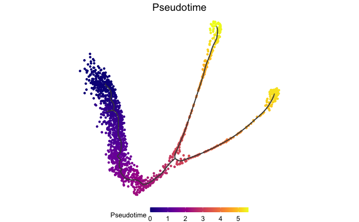

#### Check how well it correlates with the original pseudotime

when pseudotime was calculated on the whole object

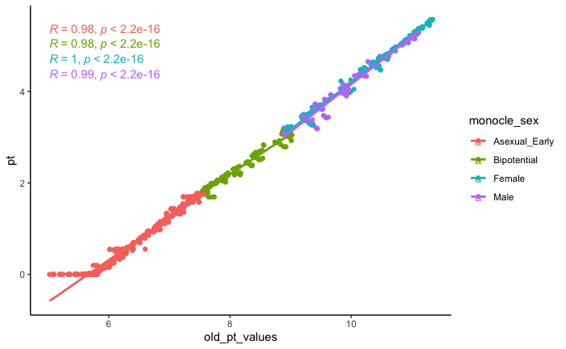

```r
library(ggpubr)
## extract pseudotime values:
pt_values_new <- as.data.frame(pseudotime(monocle.object, reduction_method = "UMAP"))
pt_values_new$cell_name <- rownames(pt_values_new)
meta_data_df <- as.data.frame(monocle.object@colData)
meta_data_df$cell_name <- rownames(meta_data_df)
meta_data_df <- merge(meta_data_df, pt_values_new, by = "cell_name")
names(meta_data_df)[ncol(meta_data_df)]<- "pt"

ggplot(meta_data_df, aes(x = old_pt_values, y = pt, colour = monocle_sex)) +
  geom_point() +
  geom_smooth(method = "lm", se = FALSE) +
  theme_classic() + stat_cor(method = "pearson")
```

#### Module Construction

```r
## find genes that change as a function of pt:
monocle.object_pr_test_res <- graph_test(monocle.object, neighbor_graph="principal_graph", cores=8)
## find significant genes
## I used 0.05 previously in all cells
## 2884 w. p = 0.01, 3260 w. p = 0.05
pr_deg_ids <- row.names(subset(monocle.object_pr_test_res, q_value < 0.05))

## collect into modules
gene_module_df_sex <- find_gene_modules(monocle.object[pr_deg_ids,], resolution=c(10^seq(-6,2)), random_seed = 1234)
```

```
Found more than one class "dist" in cache; using the first, from namespace 'BiocGenerics'
Also defined by ‘spam’
Found more than one class "dist" in cache; using the first, from namespace 'BiocGenerics'
Also defined by ‘spam’
```

```r
## how many genes in modules?
dim(gene_module_df_sex)
```

```
[1] 3417    5
```

[output not shown]

## Plot Modules

#### General Module Composition

Make a dataframe to plot by aggregating clusters vs. modules

```r
## make cell group df
cell_group_df <- tibble::tibble(cell=row.names(colData(monocle.object)), cell_group=colData(monocle.object)$seurat_clusters)

## make plotting df
agg_mat <- aggregate_gene_expression(monocle.object, gene_module_df_sex, cell_group_df)
```

Find out how many genes there are per total so we can add this to the plot

```r
## how many genes per module?
genes_per_module <- as.data.frame(table(gene_module_df_sex$module))
genes_per_module
```

| Var1 | Freq |
| --- | --- |
| 1 | 306 |
| 2 | 304 |
| 3 | 271 |
| 4 | 249 |
| 5 | 228 |
| 6 | 225 |
| 7 | 224 |
| 8 | 209 |
| 9 | 165 |
| 10 | 165 |

[output cut: 8 more lines]

Find out which modules our mutant genes reside in

```r
## create a list of our mutant gene IDs
list_of_mutant_genes <- c("PBANKA-0828000", "PBANKA-1302700", "PBANKA-1447900", "PBANKA-0102400", "PBANKA-0716500", "PBANKA-1435200", "PBANKA-1418100", "PBANKA-0902300", "PBANKA-0413400", "PBANKA-1454800")

## make a dataframe to convert the gene IDs into actual IDs
ss2_mutants_final <- readRDS("../data_to_export/ss2_mutants_final.RDS")
df_mutant_ids <- as.data.frame(unique(cbind(ss2_mutants_final@meta.data$identity_gene_updated, ss2_mutants_final@meta.data$identity_updated, ss2_mutants_final@meta.data$identity_name_updated)))[-c(2),]
rm(ss2_mutants_final)
# remove the "820" bit on 10
df_mutant_ids$V1 <- gsub("_820", "", df_mutant_ids$V1)
# change the underscore (_) to a dash (-) in gene IDs
df_mutant_ids$V1 <- gsub("_", "-", df_mutant_ids$V1)
names(df_mutant_ids) <- c("gene_ID", "mutant_identity", "mutant_identity_2")

## subset modules df to include only mutant gene IDs
df_mutant_gene_modules <- as.data.frame(gene_module_df_sex[which(gene_module_df_sex$id %in% list_of_mutant_genes),])
names(df_mutant_gene_modules)[1] <- "gene_ID"

## merge dataframes
df_mutant_gene_modules <- merge(df_mutant_gene_modules, df_mutant_ids, by = "gene_ID")

## Inspect
df_mutant_gene_modules[order(df_mutant_gene_modules$module), ]
```

|  | gene_ID | module | supermodule | dim_1 | dim_2 | mutant_identity | mutant_identity_2 |
| --- | --- | --- | --- | --- | --- | --- | --- |
| 9 | PBANKA-1447900 | 2 | 1 | -0.2950131 | 3.29967763 | GCSKO-29 | md2 |
| 5 | PBANKA-0902300 | 4 | 1 | -1.3968472 | -0.06166408 | GCSKO-13 | fd2 |
| 7 | PBANKA-1418100 | 4 | 1 | -1.0091839 | 0.50423553 | GCSKO-17 | fd3 |
| 8 | PBANKA-1435200 | 4 | 1 | -1.3543994 | -0.03988359 | GCSKO-20 | fd4 |
| 10 | PBANKA-1454800 | 4 | 1 | -1.3987260 | 0.01541641 | GCSKO-21 | fd1 |
| 2 | PBANKA-0413400 | 5 | 1 | -1.1762469 | 1.78786590 | GCSKO-10_820 | md5 |
| 3 | PBANKA-0716500 | 5 | 1 | 0.2614334 | 1.80302265 | GCSKO-19 | md4 |
| 4 | PBANKA-0828000 | 5 | 1 | -0.0986927 | 1.33581569 | GCSKO-3 | gd1 |
| 6 | PBANKA-1302700 | 16 | 1 | 1.8298230 | 1.04005363 | GCSKO-oom | md1 |
| 1 | PBANKA-0102400 | 18 | 1 | 1.0448324 | 2.16974380 | GCSKO-2 | md3 |

so modules of interest are:

```r
table(df_mutant_gene_modules$module)
```

```
 1  2  3  4  5  6  7  8  9 10 11 12 13 14 15 16 17 18
 0  1  0  4  3  0  0  0  0  0  0  0  0  0  0  1  0  1
```

Which modules do other genes of interest lie in?:

```r
## landmark genes (genes of interest)
# AP2G - PBANKA-1437500
# AP2 - PBANKA-0909600 - from poran paper
# AP2G-2 - PBANKA-1034300
# ccp2 - "PBANKA-1319500" - female 820
# p25 - "PBANKA-0515000" - female
# p28 - "PBANKA-0514900" - female
# ccp3 - "PBANKA-1035200" - female -  https://www.ncbi.nlm.nih.gov/pmc/articles/PMC5909122/
# nek4 - "PBANKA-0616700" - female
# ap2-fg - "PBANKA-1415700" - female
# dozi - "PBANKA-1217700" - female
# MG1 - "PBANKA-0416100" - male 820
# hap2 - "PBANKA-1212600" - male
# MAPK2 - "PBANKA-0933700" - male
# nek1 - "PBANKA-1443000" - male
# cdpk4 - "PBANKA-0615200" - male

## create a list of landmark genes
list_of_landmark_genes <- c("PBANKA-1437500",
                            "PBANKA-0909600",
                            "PBANKA-1034300",
                            "PBANKA-1319500",
                            "PBANKA-0515000",
                            "PBANKA-0514900",
                            "PBANKA-1035200",
                            "PBANKA-0616700",
                            "PBANKA-1415700",
                            "PBANKA-1217700",
                            "PBANKA-0416100",
                            "PBANKA-1212600",
                            "PBANKA-0933700",
                            "PBANKA-1443000",
                            "PBANKA-0615200")

name_of_landmark_genes <- c("AP2-G",
                            "AP2_poran",
                            "AP2-G2",
                            "ccp2",
                            "p25",
                            "p28",
                            "ccp3",
                            "nek4",
                            "ap2-fg",
                            "DOZI",
                            "mg1",
                            "hap2",
                            "mapk2",
                            "nek1",
                            "cdpk4")

## make a df
name_of_landmark_genes <- data.frame("gene_name" = name_of_landmark_genes, "id" = list_of_landmark_genes)

## make dataframe
df_landmark_gene_modules <- gene_module_df_sex[which(gene_module_df_sex$id %in% list_of_landmark_genes),]

## merge dataframes
df_landmark_gene_modules <- merge(df_landmark_gene_modules, name_of_landmark_genes, by = "id")

## inspect
df_landmark_gene_modules[order(df_landmark_gene_modules$module), ]
```

|  | id | module | supermodule | dim_1 | dim_2 | gene_name |
| --- | --- | --- | --- | --- | --- | --- |
| 1 | PBANKA-0416100 | 2 | 1 | -0.1096733 | 3.03324678 | mg1 |
| 6 | PBANKA-0933700 | 2 | 1 | -0.7688607 | 3.69883993 | mapk2 |
| 9 | PBANKA-1212600 | 2 | 1 | -0.4962253 | 2.72360494 | hap2 |
| 14 | PBANKA-1443000 | 2 | 1 | -0.2938942 | 3.20338800 | nek1 |
| 10 | PBANKA-1217700 | 4 | 1 | -1.1519813 | -0.09613917 | DOZI |
| 7 | PBANKA-1034300 | 5 | 1 | -0.5310133 | 1.07606032 | AP2-G2 |
| 5 | PBANKA-0616700 | 11 | 1 | -2.4235163 | 0.32571032 | nek4 |
| 8 | PBANKA-1035200 | 11 | 1 | -2.8559356 | -0.11184666 | ccp3 |
| 2 | PBANKA-0514900 | 12 | 1 | -4.3954141 | -0.64469526 | p28 |
| 3 | PBANKA-0515000 | 12 | 1 | -4.3435953 | -0.74799082 | p25 |

[output cut: 4 more lines]

enrichment of screen hits in modules

```r
## read in screen hits
library("readxl")
screen_hits <- read_excel("../data/Screen/Modules_Clusters_Phenotypes.xlsx")

## get only hits
screen_hits_selected <- screen_hits[which(screen_hits$`Gam phenotype screen` == "Both" | screen_hits$`Gam phenotype screen` == "Females" | screen_hits$`Gam phenotype screen` == "Males"), ]

## extract gene IDs
gene_hits <- screen_hits_selected$`new gene ID`
## change the underscore to a dash
gene_hits <- gsub("_", "-", gene_hits)

## find out which modules they are in
df_hits_gene_modules <- gene_module_df_sex[which(gene_module_df_sex$id %in% gene_hits),]
print("screen hits by module")
```

```
[1] "screen hits by module"
```

```r
table(df_hits_gene_modules$module)
```

```
 1  2  3  4  5  6  7  8  9 10 11 12 13 14 15 16 17 18
 1  1  2  7  7  0  0  0  1  1  0  0  0  0  1  3  0  1
```

```r
## get the number genes screened in that module
screen_hits_screened <- screen_hits[which(screen_hits$`Gam phenotype screen` == "Both" | screen_hits$`Gam phenotype screen` == "Females" | screen_hits$`Gam phenotype screen` == "Males" | screen_hits$`Gam phenotype screen` == "None" | screen_hits$`Gam phenotype screen` == "male not enough power"), ]
## extract gene IDs
genes_screened <- screen_hits_screened$`new gene ID`
## change the underscore to a dash
genes_screened <- gsub("_", "-", genes_screened)
## find out which modules they are in
df_screened_gene_modules <- gene_module_df_sex[which(gene_module_df_sex$id %in% genes_screened),]
print("total genes screened in this module")
```

```
[1] "total genes screened in this module"
```

```r
table(df_screened_gene_modules$module)
```

```
  1   2   3   4   5   6   7   8   9  10  11  12  13  14  15  16  17  18
 47 112  50  67  50  28  37  69  20  26  61  51  24  40  31  28   6  27
```

```r
## make a table with this info
pc_screened <- data.frame(hits = table(df_hits_gene_modules$module), screened =  table(df_screened_gene_modules$module))[,-3]
names(pc_screened) <- c("module", "hits", "screened")
pc_screened$pc <- (pc_screened$hits /pc_screened$screened)*100

## view
pc_screened
```

| module | hits | screened | pc |
| --- | --- | --- | --- |
| 1 | 1 | 47 | 2.1276596 |
| 2 | 1 | 112 | 0.8928571 |
| 3 | 2 | 50 | 4.0000000 |
| 4 | 7 | 67 | 10.4477612 |
| 5 | 7 | 50 | 14.0000000 |
| 6 | 0 | 28 | 0.0000000 |
| 7 | 0 | 37 | 0.0000000 |
| 8 | 0 | 69 | 0.0000000 |
| 9 | 1 | 20 | 5.0000000 |
| 10 | 1 | 26 | 3.8461538 |

[output cut: 8 more lines]

Further investigation of screen hits

```r
## rename df
df_screen_hits_selected <- as.data.frame(screen_hits_selected)
df_screen_hits_selected$'new gene ID' <- gsub("_", "-", df_screen_hits_selected$'new gene ID')
names(df_screen_hits_selected)[2] <- "id"
df_gene_module_df_sex <- as.data.frame(gene_module_df_sex)

## merge dfs together
screen_hits_modules <- merge(df_screen_hits_selected, df_gene_module_df_sex, by = "id")

## view
screen_hits_modules
```

| id | gene | Annotation | A&A Modules | Kasia Cluster | Validation number | Name | Gam phenotype screen | Asex growh | BSPhenotype | MvsF expression | module | supermodule | dim_1 | dim_2 |
| --- | --- | --- | --- | --- | --- | --- | --- | --- | --- | --- | --- | --- | --- | --- |
| PBANKA-0102200 | PBANKA_010220 | "trophozoite exported protein 1, putative (TEX1)" | 4 | 32 | NA | NA | Males | 1.0160703 | Dispensable | -1.13791296 | 10 | 1 | 1.59941770 | -0.45686886 |
| PBANKA-0102400 | PBANKA_010240 | "conserved Plasmodium protein, unknown function" | 12 | 60 | # 2 | MD1 | Males | 0.9845314 | Dispensable | 0.78003807 | 18 | 1 | 1.04483236 | 2.16974380 |
| PBANKA-0105300 | PBANKA_010530 | "conserved Plasmodium protein, unknown function" | NA | 40 | NA | NA | Both | 0.9018449 | Dispensable | -0.72943314 | 4 | 1 | -0.05251618 | 0.33086445 |
| PBANKA-0311900 | PBANKA_031190 | "RING zinc finger protein, putative" | NA | 2 | NA | NA | Females | 0.7948158 | Slow | -0.43521269 | 5 | 1 | -0.18178587 | 0.67739036 |
| PBANKA-0401100 | PBANKA_040110 | "serine/threonine protein kinase, putative (SRPK1)" | NA | 64 | NA | NA | Males | 0.6616824 | Slow | 0.57735298 | 5 | 1 | -0.81922267 | 1.73522165 |
| PBANKA-0409100 | PBANKA_040910 | "pre-mRNA splicing factor, putative" | 6 | 6 | NA | NA | Both | 0.5486783 | Slow | 0.94062453 | 1 | 1 | 0.76616968 | -0.72783349 |
| PBANKA-0410500 | PBANKA_041050 | "transporter, putative" | 13 | 55 | # 24 | MFR3 | Females | 0.9699906 | Dispensable | 1.65233123 | 3 | 1 | 2.14477529 | -1.39249442 |
| PBANKA-0413400 | PBANKA_041340 | "conserved Plasmodium protein, unknown function" | NA | 59 | # 10 | MD5 | Males | 1.0401440 | Dispensable | 1.97295129 | 5 | 1 | -1.17624687 | 1.78786590 |
| PBANKA-0712300 | PBANKA_071230 | "zinc finger protein, putative" | 8 | 54 | NA | NA | Females | 0.8395783 | Slow | 1.57084206 | 15 | 1 | -1.52406333 | 0.99213149 |
| PBANKA-0713500 | PBANKA_071350 | "asparagine-rich antigen, putative, fragment" | 12 | 63 | # 27 | MD4 | Males | 1.0119300 | Dispensable | -1.64700660 | 16 | 1 | 1.67464186 | 1.20803811 |

[output cut: 15 more lines]

DOZI-regulated genes

Find out how many of the genes in each module has a DOZI-regulated gene

```r
DOZI_regulated_genes <-
read.csv(file = "../data/Reference/DOZI_regulated_genes.csv", header = TRUE)

## extract gene IDs
dozi_genes <- DOZI_regulated_genes[DOZI_regulated_genes$DOZI_regulated. == "YES", ]$Gene_ID_PB
## change the underscore to a dash
dozi_genes <- gsub("_", "-", dozi_genes)

## find out which modules they are in
df_dozi_gene_modules <- gene_module_df_sex[which(gene_module_df_sex$id %in% dozi_genes),]
print("dozi genes by module")
```

```
[1] "dozi genes by module"
```

```r
table(df_dozi_gene_modules$module)
```

```
 1  2  3  4  5  6  7  8  9 10 11 12 13 14 15 16 17 18
 9  2 15  5  4  6 11 95  5  4 14 50  8  7  4  7  1  0
```

#### Visualise module expression

plot out modules

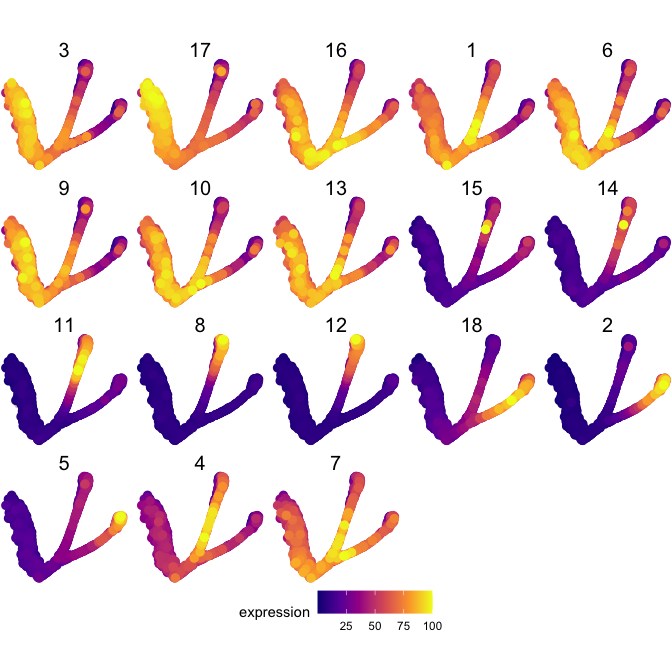

```r
## make aggregated df again so you can edit it
agg_mat <- aggregate_gene_expression(monocle.object, gene_module_df_sex, cell_group_df)

## h clust the aggregated matrix
module_dendro <- hclust(dist(agg_mat))

## use these clusters to reorder the modules
gene_module_df_sex$module <- factor(gene_module_df_sex$module, levels = row.names(agg_mat)[module_dendro$order])

## plot
UMAP_modules <- plot_cells(monocle.object, genes=gene_module_df_sex %>% filter(module %in% c(1:20)),
           cell_size = 2,
           x = 1, y = 2,
           label_cell_groups=FALSE,
           scale_to_range = TRUE,
           show_trajectory_graph=FALSE) +
                          scale_colour_viridis_c(name = "expression", option = "C", alpha = 1) +
                          coord_fixed() +
                          theme_void() +
                          theme(legend.position = "bottom", strip.text.x = element_text(size = 15))
## view
UMAP_modules
```

save

```r
#ggsave("../images_to_export/GCSKO_sexbranch_umap_modules.png", plot = UMAP_modules, device = "png", path = NULL, scale = 1, width = 30, height = 30, units = "cm", dpi = 300, limitsize = TRUE)
```

```r
## make a dataframe of genes per module
genes_per_module <- as.data.frame(table(gene_module_df_sex$module))

## inspect
genes_per_module
```

| Var1 | Freq |
| --- | --- |
| 3 | 271 |
| 17 | 122 |
| 16 | 136 |
| 1 | 306 |
| 6 | 225 |
| 9 | 165 |
| 10 | 165 |
| 13 | 140 |
| 15 | 136 |
| 14 | 139 |

[output cut: 8 more lines]

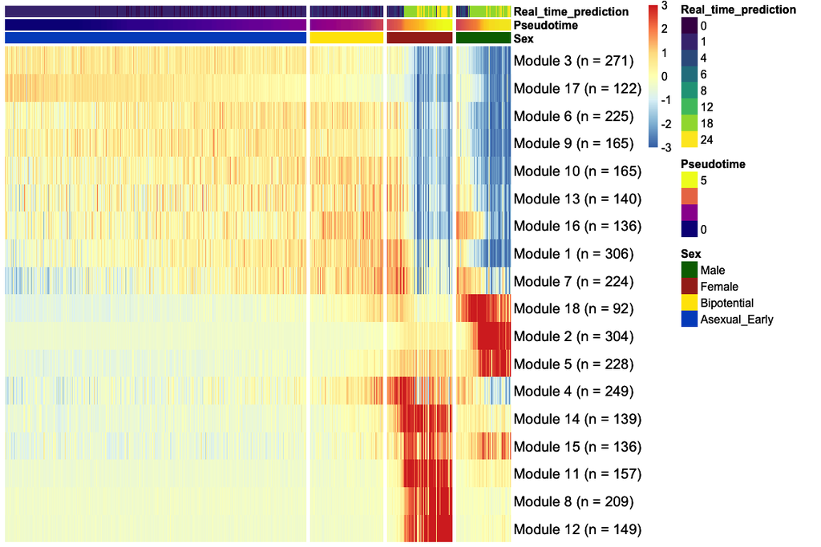

save

```r
ggsave("../images_to_export/GCSKO_sexbranch_heatmap.png", plot = heatmap_main, device = "png", path = NULL, scale = 1, width = 21, height = 21, units = "cm", dpi = 300, limitsize = TRUE)
```

# 4. Mapping on mutants

Seurat method

```r
pancreas.anchors <- FindTransferAnchors(reference = seurat.object, query = SMARTSEQ,
    dims = 1:30)
predictions <- TransferData(anchorset = pancreas.anchors, refdata = seurat.object$monocle_sex,
    dims = 1:30)
pancreas.query <- AddMetaData(pancreas.query, metadata = predictions)
```

# Final Figures

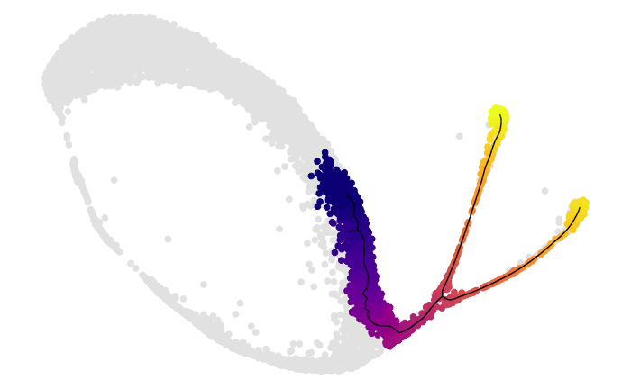

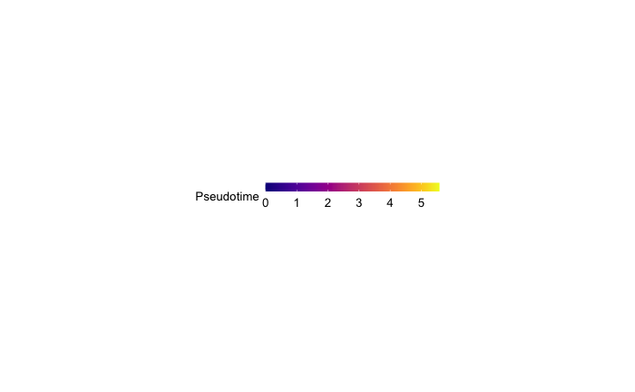

```r
# Extract the legend. Returns a gtable
leg <- get_legend(umap_pt)

# Convert to a ggplot and print
as_ggplot(leg)
```

save

```r
ggsave("../images_to_export/Figure_D.png", plot = umap_zoom_plot, device = "png", path = NULL, scale = 1, width = 21, height = 29.7, units = "cm", dpi = 300, limitsize = TRUE)
ggsave("../images_to_export/Figure_D_legend.png", plot = legend_d, device = "png", path = NULL, scale = 1, width = 21, height = 29.7, units = "cm", dpi = 300, limitsize = TRUE)
```

# Appendix

### Scaling values in the aggregated heatmap

```r
getAnywhere(aggregate_gene_expression)
```

```
A single object matching ‘aggregate_gene_expression’ was found
It was found in the following places
  package:monocle3
  namespace:monocle3
with value

function (cds, gene_group_df = NULL, cell_group_df = NULL, norm_method = c("log",
    "binary", "size_only"), pseudocount = 1, scale_agg_values = TRUE,
    max_agg_value = 3, min_agg_value = -3, exclude.na = TRUE)
{
    if (is.null(gene_group_df) && is.null(cell_group_df))
        stop("Error: one of either gene_group_df or cell_group_df must not be NULL")
    agg_mat <- normalized_counts(cds, norm_method = norm_method,
        pseudocount = pseudocount)
    if (is.null(gene_group_df) == FALSE) {
        gene_group_df <- as.data.frame(gene_group_df)
        gene_group_df <- gene_group_df[gene_group_df[, 1] %in%
            fData(cds)$gene_short_name | gene_group_df[, 1] %in%
            row.names(fData(cds)), , drop = FALSE]
        short_name_mask <- gene_group_df[[1]] %in% fData(cds)$gene_short_name
        if (any(short_name_mask)) {
            geneids <- as.character(gene_group_df[[1]])
            geneids[short_name_mask] <- row.names(fData(cds))[match(geneids[short_name_mask],
                fData(cds)$gene_short_name)]
            gene_group_df[[1]] <- geneids
        }
        agg_mat = as.matrix(my.aggregate.Matrix(agg_mat[gene_group_df[,
            1], ], as.factor(gene_group_df[, 2]), fun = "sum"))
        if (scale_agg_values) {
            agg_mat <- t(scale(t(agg_mat)))
            agg_mat[agg_mat < min_agg_value] <- min_agg_value
            agg_mat[agg_mat > max_agg_value] <- max_agg_value
        }
    }
    if (is.null(cell_group_df) == FALSE) {
        cell_group_df <- as.data.frame(cell_group_df)
        cell_group_df <- cell_group_df[cell_group_df[, 1] %in%
            row.names(pData(cds)), , drop = FALSE]
        agg_mat <- agg_mat[, cell_group_df[, 1]]
        agg_mat <- my.aggregate.Matrix(Matrix::t(agg_mat), as.factor(cell_group_df[,
            2]), fun = "mean")
        agg_mat <- Matrix::t(agg_mat)
    }
    if (exclude.na) {
        agg_mat <- agg_mat[rownames(agg_mat) != "NA", colnames(agg_mat) !=
            "NA", drop = FALSE]
    }
    return(agg_mat)
}
<bytecode: 0x7ff952617628>
<environment: namespace:monocle3>
```

```r
agg_mat = as.matrix(monocle3::my.aggregate.Matrix(agg_mat[gene_group_df[,1], ], as.factor(gene_group_df[, 2]), fun = "sum"))
```

[output not shown]

```r
## get an idea of the spread of z-score values
# test <- (agg_mat_no_group)
# rowRanges(test)
# rowMeans(test)
# test <- t(agg_mat_no_group)
# names(test) = make.names(test)
# test = melt(test)
# ggplot(test, aes(x = Var2, y = value, group = Var2)) + geom_violin()
# rm(test)
```

In conclusion, the plots will look different if scaling is done by heatmap as it does not do the relimiting - i.e. anything < -3 and 3 < for the z-scores. the scaling is done on the transformed columns (e.g. when applying ‘scale’ to a matrix, it does it in a column-wise manner) which in this case, the modules are columns and so it does the correct scaling required. This is because the input is normalised cell counts and so the cells have already been scaled.